# Whole Game: Analyzing deforestation

## 0.1 Introduction

For this module, we’ll focus on generating a report using targets. We’ll create each result as a series of targets, including them in `_targets.R`. We’ll iterate through, one or two targets at a time, running `tar_make()` and `tar_visnetwork()` to check our work. Check `exercises.Rmd` for guidance on creating this report! This will be an intentionally simplified report: we’ll focus on the basics of creating output as targets and including them here as rendered material.

## 0.2 Methods

In this analysis, we look at the net change in forestation in 2010 as well as the causes of deforestation in Brazil. These data come from [Our World in Data](https://ourworldindata.org/forests-and-deforestation).

## 0.3 Results

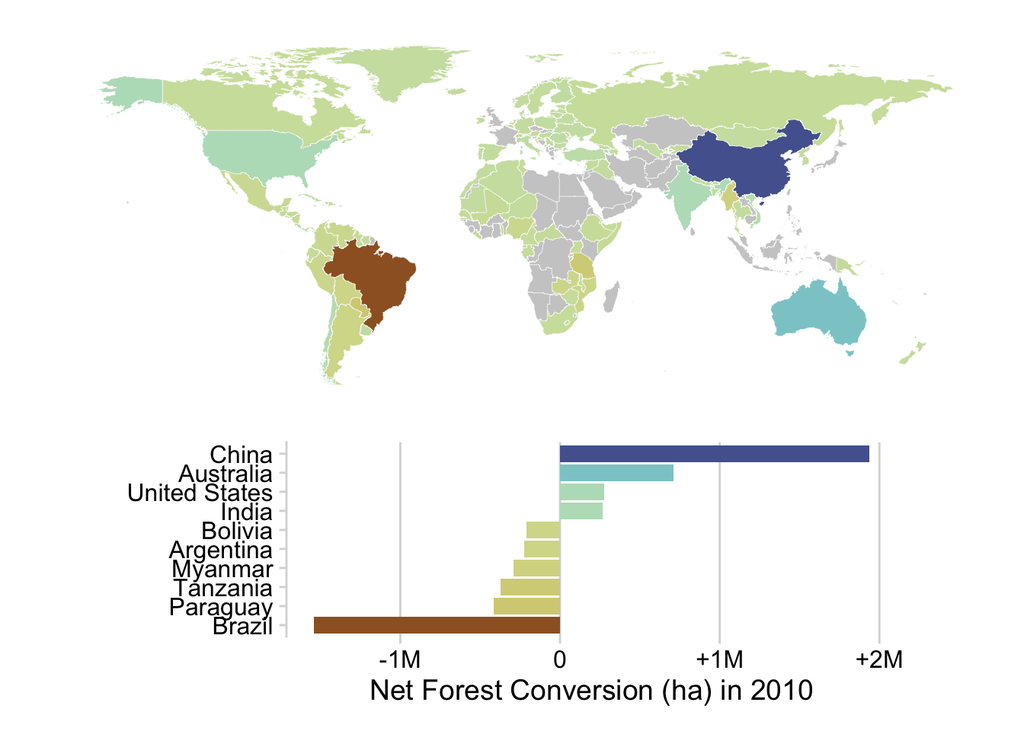

Figure 1: Net Forest Conversion in 2010

Figure 1 presents a map of net forest conversion in 2010, as well as the 10 countries with the highest absolute change in forest. In 2010, the China gained more forest than any other country, a net growth of 1,936,770 hectacres; Brazil lost more forest than any other country, a net loss of -1,539,180 hectacres.

Table 1: Causes of Brazilian forest loss in 2010

|  | *Cause* | *Hectacres* |
| --- | --- | --- |
|  | Pasture | 616,000 |
|  | Fire | 537,000 |
|  | Small scale clearing | 271,000 |
|  | Selective logging | 114,000 |
|  | Commercial crops | 100,000 |
|  | Natural disturbances | 44,000 |
|  | Roads | 22,000 |
|  | Other infrastructure | 9,000 |
|  | Tree plantations including palm | 9,000 |
|  | Mining | 4,000 |
|  | Flooding due to dams | 0 |
| Total |  | 1,726,000 |

Table 1 shows the causes of deforestation in Brazil in 2010. The top cause was clearing for pasture (616,000 hectacres), followed by fire (537,000 hectacres), then small scale clearing (271,000 hectacres).

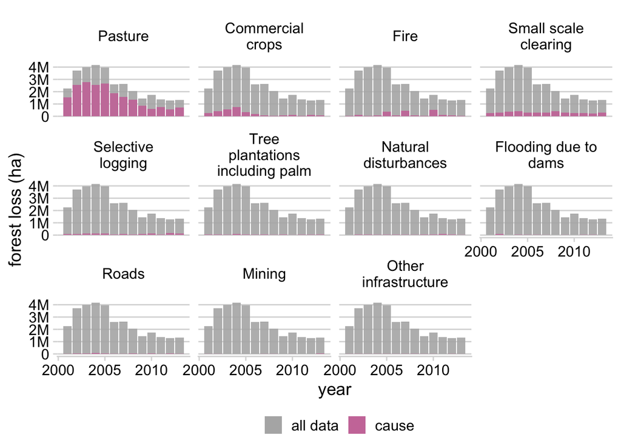

Figure 2: Causes of deforestation in Brazil over time, sorted by maximum loss

Figure 2 shows that, while deforestation has decreased in Brazil since the early 2000s, it remains steady at over 1 million hectacres lost per year. Pasture clearing is consistently the top cause, while fire—generally being accidental—varies from year to year.

## 0.4 Discussion

We’ve combined the magic of R Markdown for generating reports with the reliability of targets for managing our code, when we render the report, and understanding what targets the report depends on. targets also let’s us focus more on communicating and less on including lots of code in our report; it’s all handled by our pipeline. Using `tar_load()` and `tar_read()` allows us to grab targets and associated them with this report!

## References

Brownrigg, Ray. 2018. *Maps: Draw Geographical Maps*. https://CRAN.R-project.org/package=maps.

Henry, Lionel, and Hadley Wickham. 2020. *Purrr: Functional Programming Tools*. https://CRAN.R-project.org/package=purrr.

Iannone, Richard, Joe Cheng, and Barret Schloerke. 2021. *Gt: Easily Create Presentation-Ready Display Tables*.

Landau, William Michael. 2021a. *Tarchetypes: Archetypes for Targets*. https://CRAN.R-project.org/package=tarchetypes.

———. 2021b. *Tarchetypes: Archetypes for Targets*.

———. 2021c. *Targets: Dynamic Function-Oriented Make-Like Declarative Workflows*. https://CRAN.R-project.org/package=targets.

———. 2021d. “The Targets r Package: A Dynamic Make-Like Function-Oriented Pipeline Toolkit for Reproducibility and High-Performance Computing.” *Journal of Open Source Software* 6 (57): 2959. https://doi.org/10.21105/joss.02959.

Müller, Kirill, and Hadley Wickham. 2021. *Tibble: Simple Data Frames*. https://CRAN.R-project.org/package=tibble.

Pebesma, Edzer. 2018. “Simple Features for R: Standardized Support for Spatial Vector Data.” *The R Journal* 10 (1): 439–46. https://doi.org/10.32614/RJ-2018-009.

———. 2021. *Sf: Simple Features for r*. https://CRAN.R-project.org/package=sf.

Pedersen, Thomas Lin. 2020. *Patchwork: The Composer of Plots*. https://CRAN.R-project.org/package=patchwork.

Pedersen, Thomas Lin, and Fabio Crameri. 2020. *Scico: Colour Palettes Based on the Scientific Colour-Maps*. https://github.com/thomasp85/scico.

R Core Team. 2021. *R: A Language and Environment for Statistical Computing*. Vienna, Austria: R Foundation for Statistical Computing. https://www.R-project.org/.

Wickham, Hadley. 2016. *Ggplot2: Elegant Graphics for Data Analysis*. Springer-Verlag New York. https://ggplot2.tidyverse.org.

———. 2019. *Stringr: Simple, Consistent Wrappers for Common String Operations*. https://CRAN.R-project.org/package=stringr.

———. 2021a. *Forcats: Tools for Working with Categorical Variables (Factors)*. https://CRAN.R-project.org/package=forcats.

———. 2021b. *Tidyr: Tidy Messy Data*. https://CRAN.R-project.org/package=tidyr.

———. 2021c. *Tidyverse: Easily Install and Load the Tidyverse*. https://CRAN.R-project.org/package=tidyverse.

Wickham, Hadley, Mara Averick, Jennifer Bryan, Winston Chang, Lucy D’Agostino McGowan, Romain François, Garrett Grolemund, et al. 2019. “Welcome to the tidyverse.” *Journal of Open Source Software* 4 (43): 1686. https://doi.org/10.21105/joss.01686.

Wickham, Hadley, Winston Chang, Lionel Henry, Thomas Lin Pedersen, Kohske Takahashi, Claus Wilke, Kara Woo, Hiroaki Yutani, and Dewey Dunnington. 2020. *Ggplot2: Create Elegant Data Visualisations Using the Grammar of Graphics*. https://CRAN.R-project.org/package=ggplot2.

Wickham, Hadley, Romain François, Lionel Henry, and Kirill Müller. 2021. *Dplyr: A Grammar of Data Manipulation*. https://CRAN.R-project.org/package=dplyr.

Wickham, Hadley, and Jim Hester. 2020. *Readr: Read Rectangular Text Data*. https://CRAN.R-project.org/package=readr.